# Midterm - House Prediction

Jonathan Manurung, June Jaegal

15-12-2023

# Introduction

> The purpose of this project is to built a better predictive model of home prices for Philadelphia, in order to create better and more accurate version from the Zillow prediction. The resulting model will be used to predict some house prices in Philadelphia, based on their internal characteristic and the Amenities/Public Services nearby using statistical analysis and data-driven insights. We will use experiences from observed data, and test whether they can be used to predict outcomes where and when they are unknown. What makes this modeling exercise challenging is the abundance of potential variables and the need to select the most accurate ones that directly influence the house prices. Additionally, there is a substantial amount of missing data in the provided observed data so data cleaning and filtering need to be performed. The goal of this project is to train a model from observed data with training set, and test whether that model generalizes to properties that have unknown or un-estimated prices. A framework is used in the predictive modeling process. Data wrangling: to compile required data into one dataset and cleaning the outliers. Feature engineering: to create variables used to predict the outcome. Measuring the sum of indicators value within a fixed buffer distance of each home obeserved to see the scale relationship between the variables and home prices; Model estimation and validation: Creating an OLS Regression model that will be used to estimates the home prices as a function of several variables.

# Summary Statistics

```r
# Select the relevant columns
selected_cols3 <- c("sale_price")
data_subset3 <- philly[, selected_cols3]
data_subset3$geometry <- NULL

# Define variable descriptions
variable_descriptions <- data.frame(
  Variable = selected_cols3,
  Description = c("sale_price")
)

# Create a custom summary table with mean, median, sd, min, and max
summary_stats <- data.frame(
  Mean = sapply(data_subset3, mean, na.rm = TRUE),
  Median = sapply(data_subset3, median, na.rm = TRUE),
  SD = sapply(data_subset3, sd, na.rm = TRUE),
  Min = sapply(data_subset3, min),
  Max = sapply(data_subset3, max)
)

# Print the custom summary table using stargazer
kable(summary_stats, format = "html") %>%
  kable_styling()
```

|  | Mean | Median | SD | Min | Max |
| --- | --- | --- | --- | --- | --- |
| sale_price | 271846.8 | 228000 | 240083.4 | 0 | 5990000 |

```r
# Select the relevant columns
selected_cols2 <- c("park.Buffer", "crime.Buffer", "water.Buffer", "transit.Buffer", "pub.Buffer", "university.Buffer", "landmark.Buffer","bridge.Buffer")
data_subset2 <- philly[, selected_cols2]
data_subset2$geometry <- NULL

# Define variable descriptions
variable_descriptions <- data.frame(
  Variable = selected_cols2,
  Description = c("park.Buffer", "crimes.Buffer", "water.Buffer", "transit.Buffer", "pub.Buffer", "university.Buffer", "landmark.Buffer","bridge.Buffer")
)

# Create a custom summary table with mean, median, sd, min, and max
summary_stats <- data.frame(
  Mean = sapply(data_subset2, mean, na.rm = TRUE),
  Median = sapply(data_subset2, median, na.rm = TRUE),
  SD = sapply(data_subset2, sd, na.rm = TRUE),
  Min = sapply(data_subset2, min),
  Max = sapply(data_subset2, max)
)

# Print the custom summary table using stargazer
kable(summary_stats, format = "html") %>%
  kable_styling()
```

|  | Mean | Median | SD | Min | Max |
| --- | --- | --- | --- | --- | --- |
| park.Buffer | 1.1605460 | 0 | 1.7050333 | 0 | 10 |
| crime.Buffer | 18.1602948 | 13 | 17.5562513 | 0 | 104 |
| water.Buffer | 4.2789665 | 0 | 9.9540097 | 0 | 95 |
| transit.Buffer | 0.4700389 | 0 | 0.8583713 | 0 | 9 |
| pub.Buffer | 1.1054395 | 0 | 2.3597556 | 0 | 19 |
| university.Buffer | 0.0024287 | 0 | 0.0492231 | 0 | 1 |
| landmark.Buffer | 0.0269252 | 0 | 0.1618682 | 0 | 1 |
| bridge.Buffer | 5.9804447 | 3 | 8.1629701 | 0 | 43 |

> The summary statistic table provides an overview of key statistics for amenitie/public services variables: park, crimes, water, transit, pub, university, landmark, and bridge within the Buffer zone of each house. The high value of standard deviation in crimes buffer, water buffer, and bridge buffer show moderate to high variability in those variables.

# Correlation matrix

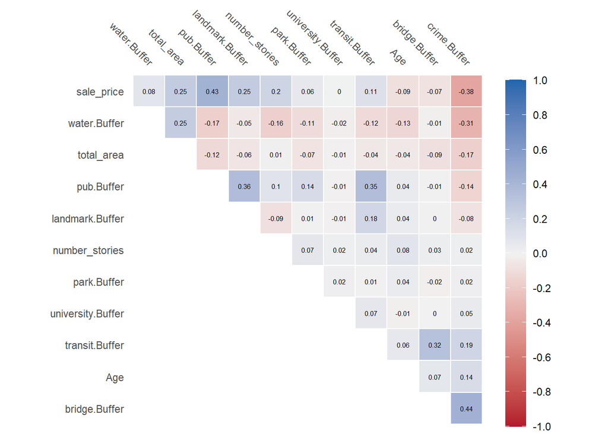

```r
corex<- philly %>% mutate(Age = 2023 - year_built) %>% dplyr::select(sale_price,park.Buffer, crime.Buffer, water.Buffer,transit.Buffer, pub.Buffer, university.Buffer, landmark.Buffer, bridge.Buffer, Age, number_stories, total_area)

numericVars <-
  select_if(st_drop_geometry(corex), is.numeric) %>% na.omit()


numericVars %>%
  correlate() %>%
  autoplot() +
  geom_text(aes(label = round(r,digits=2)),size = 2)
```

# Home Prices Scatterplots

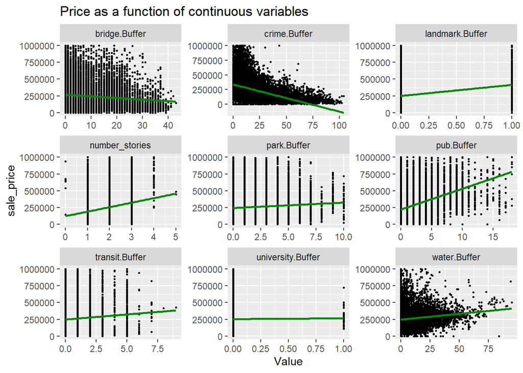

> The scatterplot illustrates the relationship between home prices and the amenities/public services variables. The subplots show associations between each variable to the price explained by the green line. Transit, Pub and Water Buffer variables show positively sloped line, indicating a positive relationship, where an increase in the variable corresponds to an increase in the home price. On the other hand, crime buffer variables indicate a negatively sloped line, suggesting a negative relationship of this variable to the home price.

# Map Home Price

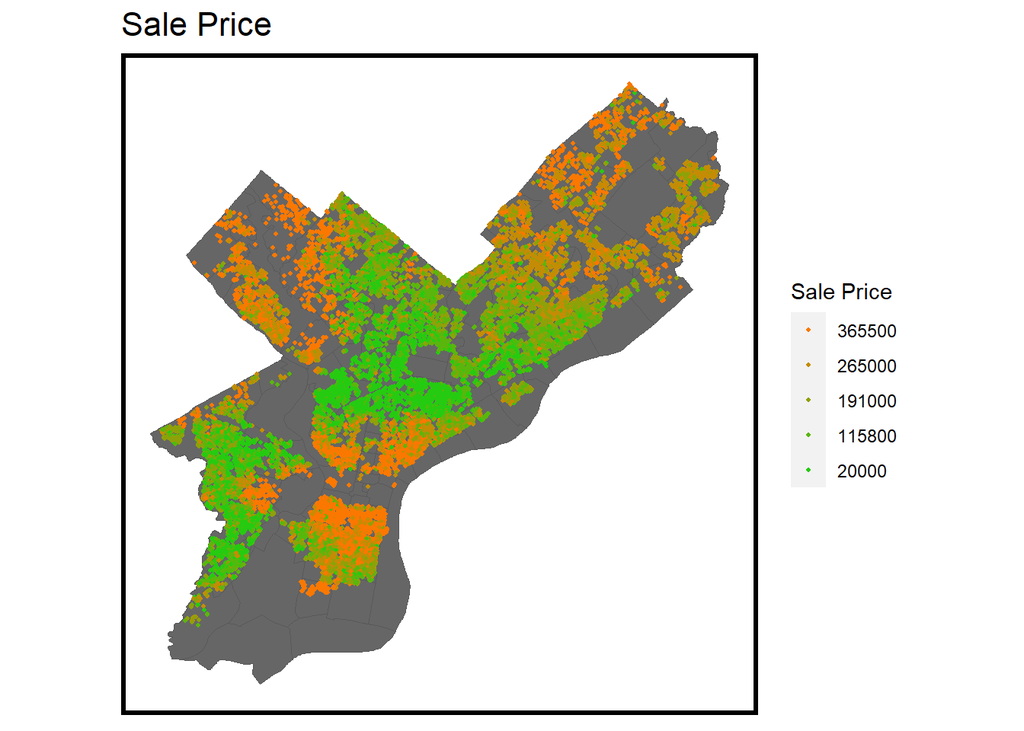

```r
# Mapping data
ggplot() +
  geom_sf(data = neighborhood, fill = "grey40") +
  geom_sf(data = philly, aes(colour = q5(sale_price)),
          show.legend = "point", size = .75) +
  scale_colour_manual(values = palette5,
                   labels=qBr(philly,"sale_price"),
                   name="Sale Price",) + guides(color = guide_legend(reverse = TRUE)) +
  labs(title="Sale Price") +
  mapTheme()
```

> The map shows the sales price. Orange color represents higher sales price and green color represents lower sales price. We can observe several orange color clustered areas.

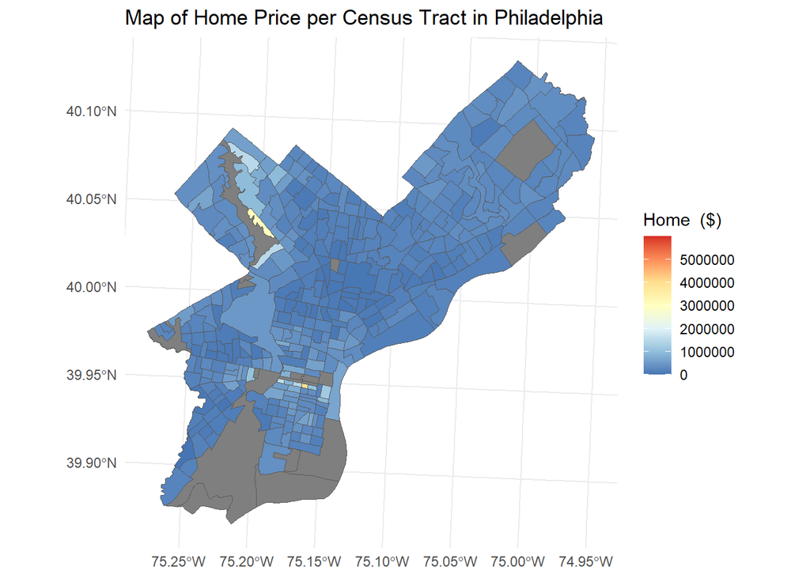

```r
merged_data <- st_join(census, philly, by = "census_tract")

breaks <- seq(0, 6000000, by = 1000000)

ggplot() +
  geom_sf(data = merged_data, aes(fill = sale_price)) +
  scale_fill_distiller(palette = "RdYlBu", direction = -1) +
  labs(title = "Map of Home Price per Census Tract in Philadelphia",
       fill = "Home  ($)") +
  theme_minimal()
```

> The map shows the distribution of Home Price across different census tracts within Philadelphia. Color-coded markers provide a visual representation of areas with varying the home price, which red color indicates higher home price in the census tract and the blue indicates lower home price.

# 3 interesting maps

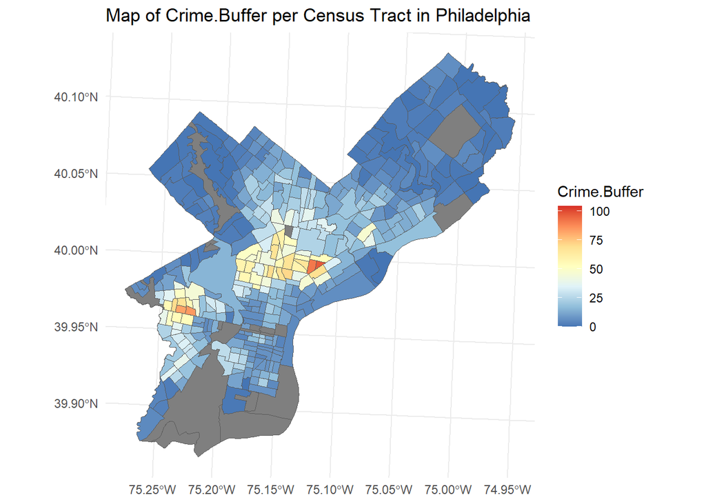

```r
# Create a ggplot to visualize the census tracts and pub buffers
ggplot() +
  geom_sf(data = merged_data, aes(fill = crime.Buffer)) +
  scale_fill_distiller(palette = "RdYlBu", name = "Crime.Buffer") +
  labs(title = "Map of Crime.Buffer per Census Tract in Philadelphia",
       fill = "Crime Buffer") +
  theme_minimal()
```

> This is a map of crime map in Philadelphia by census tracts. It shows that the crime is concentrated at the center of the Philadelphia. Also, there is another clustered area on the bottom left.

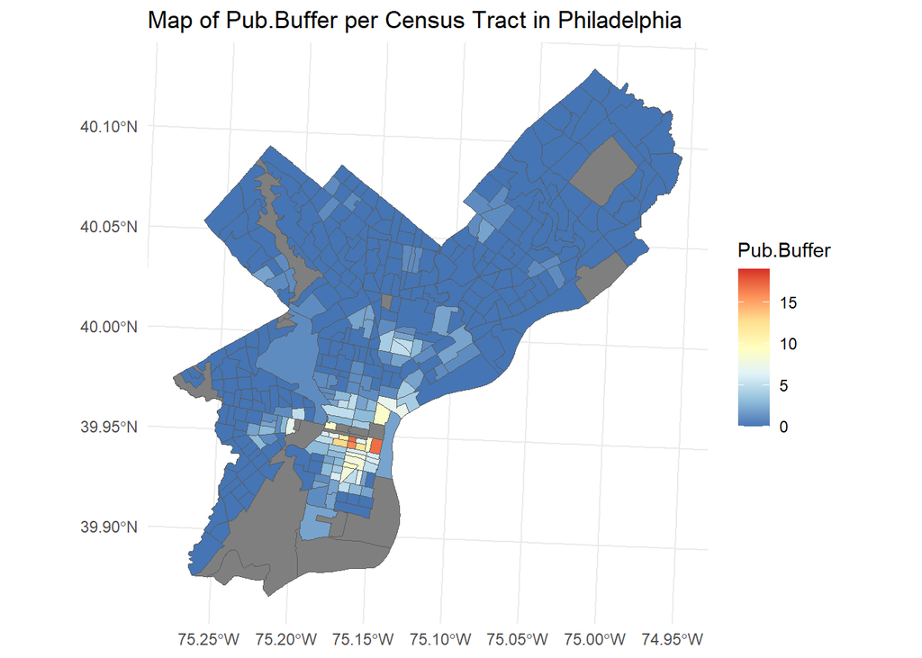

```r
# Create a ggplot to visualize the census tracts and pub buffers
ggplot() +
  geom_sf(data = merged_data, aes(fill = pub.Buffer)) +
  scale_fill_distiller(palette = "RdYlBu", name = "Pub.Buffer") +
  labs(title = "Map of Pub.Buffer per Census Tract in Philadelphia",
       fill = "Pub Buffer") +
  theme_minimal()
```

> Pubs in Philadelphia are clustered at the bottom right of the Philadelphia. Besides the clustered region, we can observe that there are not many pubs in Philadelphia.

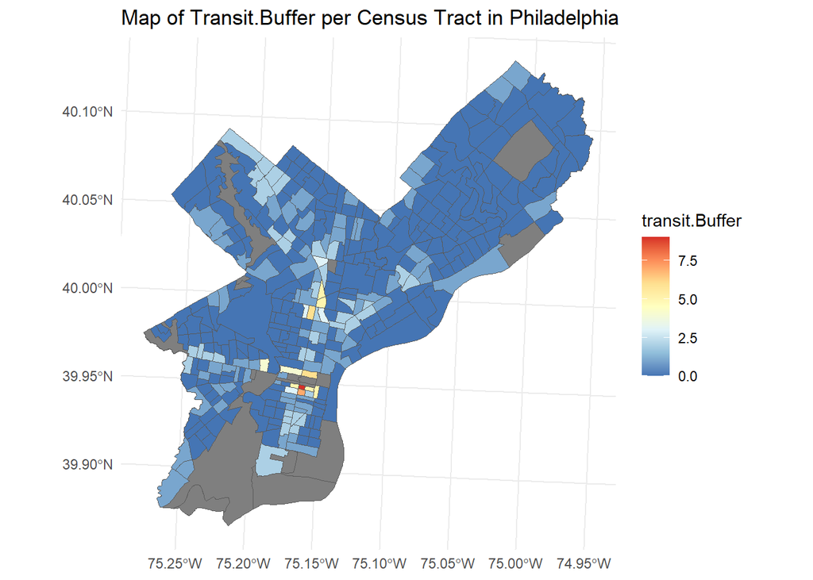

```r
# Create a ggplot to visualize the census tracts and pub buffers
ggplot() +
  geom_sf(data = merged_data, aes(fill = transit.Buffer)) +
  scale_fill_distiller(palette = "RdYlBu", name = "transit.Buffer") +
  labs(title = "Map of Transit.Buffer per Census Tract in Philadelphia",
       fill = "Transit Buffer") +
  theme_minimal()
```

> Transit options are concentrated at the bottom right of the Philadelphia. The area is around the center city. Due to high demand of the transit, transit methods are clustered to the center of the city.

# Bonus for something enganging

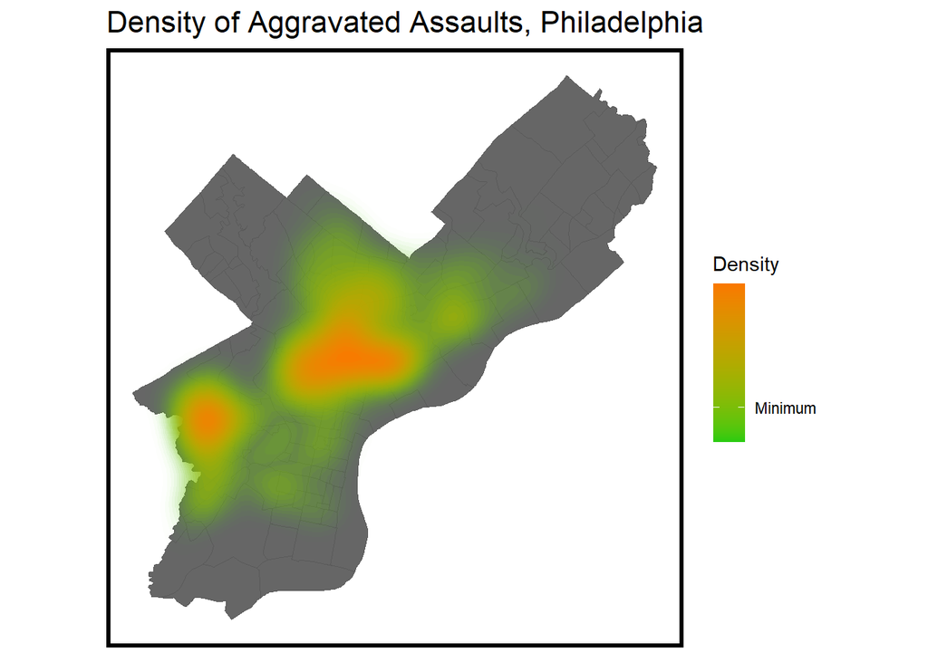

```r
ggplot() + geom_sf(data = neighborhood, fill = "grey40") +
  stat_density2d(data = data.frame(st_coordinates(crime)),
                 aes(X, Y, fill = ..level.., alpha = ..level..),
                 size = 0.01, bins = 40, geom = 'polygon') +
  scale_fill_gradient(low = "#25CB10", high = "#FA7800",
                      breaks=c(0.000000003,0.00000003),
                      labels=c("Minimum","Maximum"), name = "Density") +
  scale_alpha(range = c(0.00, 0.5), guide = FALSE) +
  labs(title = "Density of Aggravated Assaults, Philadelphia") +
  mapTheme()
```

> The heat map above demonstrates the density of aggravated assault in Philadelphia. Although the report already demonstrated the choropleth map of crime, this map effectively shows the clustered area without regarding the census tract.

# Methods

> In this prediction, it includes location of park, water surface, landmarks, bridges, universities, SEPTA, local pubs and crime data to predict the housing price. Most of the indicators used here are the common indicators when consumers consider when they purchase for the housing. Our methodology is to create buffers around the points of each indicators to estimate the impacted area around each events. Then, counted the number of events by each indicators around the building. With the dataset created through the process above, we created a trained model using the buildings with given sales_price. Lastly, applied this model to predict the housing price of the buildings with no given sales_price using “predict” function.

```r
# Filter rows with the specified value in the "toPredict" column
philly_challenge <- filter(philly, toPredict == "CHALLENGE")

philly_filtered <- filter(philly, toPredict == "MODELLING")

philly_filtered <- philly_filtered %>%
  mutate(Age = 2023 - year_built)

philly_challenge <- philly_challenge %>%
  mutate(Age = 2023 - year_built)

reg1<-lm(sale_price ~ ., data =
           st_drop_geometry(philly_filtered)%>%
           dplyr::select(sale_price,park.Buffer, crime.Buffer, water.Buffer,transit.Buffer, pub.Buffer, university.Buffer, landmark.Buffer, bridge.Buffer, Age, number_stories, total_area))
```

```r
set.seed(123)

inTrain <- createDataPartition(
  y = paste(philly_filtered$park.Buffer, philly_filtered$crime.Buffer, philly_filtered$water.Buffer, philly_filtered$transit.Buffer, philly_filtered$pub.Buffer, philly_filtered$university.Buffer, philly_filtered$landmark.Buffer, philly_filtered$bridge.Buffer, philly_filtered$Age, philly_filtered$number_stories, philly_filtered$total_area),
  p = 0.60, list = FALSE
)

philly_filtered.training <- philly_filtered[inTrain, ]
philly_filtered.test <- philly_filtered[-inTrain, ]

reg.training <- lm(
  sale_price ~ .,
  data = as.data.frame(philly_filtered.training) %>%
    dplyr::select(sale_price, park.Buffer, crime.Buffer, water.Buffer, transit.Buffer, pub.Buffer, university.Buffer, landmark.Buffer, bridge.Buffer, Age, number_stories, total_area)
)
```

# Table of Result (Training Set)

```r
#Provide a polished table of your training set lm summary results (coefficients, R2 etc)
reg_summary <- tidy(reg.training)

# Display the summary results as a nice table
kable(reg_summary, format = "html", caption = "Linear Regression Summary") %>%
  kable_styling(bootstrap_options = c("striped", "hover"))
```

Linear Regression Summary

| term | estimate | std.error | statistic | p.value |
| --- | --- | --- | --- | --- |
| (Intercept) | 130858.84657 | 5263.9909364 | 24.859246 | 0.0000000 |
| park.Buffer | 3838.45717 | 711.8964348 | 5.391876 | 0.0000001 |
| crime.Buffer | -4142.32760 | 83.1924723 | -49.792096 | 0.0000000 |
| water.Buffer | 434.31997 | 135.5721157 | 3.203608 | 0.0013590 |
| transit.Buffer | 3392.48121 | 1619.8062205 | 2.094375 | 0.0362375 |
| pub.Buffer | 36709.70371 | 613.1265060 | 59.872968 | 0.0000000 |
| university.Buffer | 96592.60802 | 24725.1829236 | 3.906649 | 0.0000939 |
| landmark.Buffer | 229878.48707 | 8538.1741694 | 26.923612 | 0.0000000 |
| bridge.Buffer | 2256.54437 | 171.7349176 | 13.139695 | 0.0000000 |
| Age | -367.09345 | 23.5015839 | -15.619945 | 0.0000000 |
| number_stories | 77852.71351 | 2239.9620944 | 34.756264 | 0.0000000 |
| total_area | 16.06898 | 0.3223745 | 49.845695 | 0.0000000 |

> Table of Training set show the summary result of lm regression. Besides transit and water varaible, p-value is near to 0 which means that they are statistically significant. In addition, age and crime variable have the negative quantitative effect to the model.

# Table of Goodness of fit (Test Set)

```r
philly_filtered.test <-
  philly_filtered.test %>%
  mutate(Regression = "Baseline Regression",
         sale_price.Predict = predict(reg.training, philly_filtered.test),
         sale_price.Error = sale_price.Predict - sale_price,
         sale_price.AbsError = abs(sale_price.Predict - sale_price),
         sale_price.APE = (abs(sale_price.Predict - sale_price)) / sale_price.Predict)%>%
  filter(sale_price < 5000000)
```

```r
mae_test <- mean(philly_filtered.test$sale_price.AbsError, na.rm = T)
mae_std_dev <- sd(philly_filtered.test$sale_price.AbsError, na.rm = T)
mape_test <- mean(philly_filtered.test$sale_price.APE, na.rm = T)
mape_std_dev <- sd(philly_filtered.test$sale_price.APE, na.rm = T)

# Create a data frame with the results
results <- data.frame(
  Metric = c("Mean Absolute Error (MAE)","Standard Deviation Absolute Error (MAPE)", "Mean Absolute Percentage Error (MAPE)", "Standard Deviation Absolute Percentage Error (MAPE)"),
  Value = c(mae_test,mae_std_dev, mape_test, mape_std_dev)
)

# Display the table
library(knitr)
library(kableExtra)

kable(results, format = "html", col.names = c("Metric", "Value"), align = "c") %>%
  kable_styling(full_width = FALSE)
```

| Metric | Value |
| --- | --- |
| Mean Absolute Error (MAE) | 150306.1009343 |
| Standard Deviation Absolute Error (MAPE) | 233944.4857125 |
| Mean Absolute Percentage Error (MAPE) | 0.3965553 |
| Standard Deviation Absolute Percentage Error (MAPE) | 0.5008576 |

# CV Result

Linear Regression

23781 samples 11 predictor

No pre-processing Resampling: Cross-Validated (100 fold) Summary of sample sizes: 23542, 23542, 23544, 23544, 23544, 23542, … Resampling results:

RMSE Rsquared MAE  
177686.8 0.450297 102414.1

Tuning parameter ‘intercept’ was held constant at a value of TRUE

[figure not shown]

```r
ggplot(result, aes(x = RMSE)) +
  geom_histogram(fill = "skyblue", color = "black", bins = 30) +
  labs(title = "Histogram of Cross-Validation MAE",
       subtitle = "k-fold cross-validation; k=100",
       x = "Mean Absolute Error (MAE)",
       y = "Frequency")
```

# Pred vs Obs Scatterplot

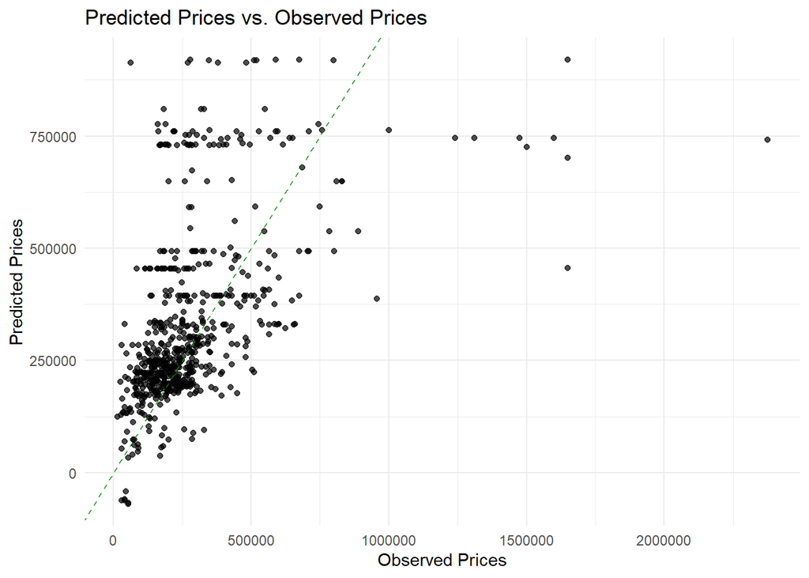

```r
ggplot(filter(philly_filtered.test, sale_price < 3000000), aes(x = sale_price, y = sale_price.Predict)) +
  geom_point(color = "black", alpha = 0.7) +
  geom_abline(intercept = 0, slope = 1, linetype = "dashed", color = "green4") +
  labs(
    title = "Predicted Prices vs. Observed Prices",
    x = "Observed Prices",
    y = "Predicted Prices"
  ) +
  theme_minimal()
```

```r
inTrain <- createDataPartition(
              y = paste(philly_filtered$name, philly_filtered$park.Buffer, philly_filtered$crime.Buffer, philly_filtered$water.Buffer, philly_filtered$transit.Buffer, philly_filtered$pub.Buffer, philly_filtered$university.Buffer, philly_filtered$landmark.Buffer, philly_filtered$bridge.Buffer, philly_filtered$Age, philly_filtered$number_stories, philly_filtered$total_area),
              p = .60, list = FALSE)
philly_filtered.training <- philly_filtered[inTrain,]
philly_filtered.test <- philly_filtered[-inTrain,]

reg.training <-
  lm(sale_price ~ ., data = as.data.frame(philly_filtered.training) %>%
                             dplyr::select(sale_price, park.Buffer, crime.Buffer, water.Buffer,transit.Buffer, pub.Buffer, university.Buffer, landmark.Buffer, bridge.Buffer, Age, number_stories, total_area ))

philly_filtered.test <-
  philly_filtered.test %>%
  mutate(Regression = "Baseline Regression",
         sale_price.Predict = predict(reg.training, philly_filtered.test),
         sale_price.Error = sale_price.Predict - sale_price,
         sale_price.AbsError = abs(sale_price.Predict - sale_price),
         sale_price.APE = (abs(sale_price.Predict - sale_price)) / sale_price.Predict)%>%
  filter(sale_price < 5000000)
```

# Residual Map

```r
coords <- st_coordinates(philly_filtered)

neighborList <- knn2nb(knearneigh(coords, 5))

spatialWeights <- nb2listw(neighborList, style="W")

philly_filtered$lagPrice <- lag.listw(spatialWeights, philly_filtered$sale_price)
```

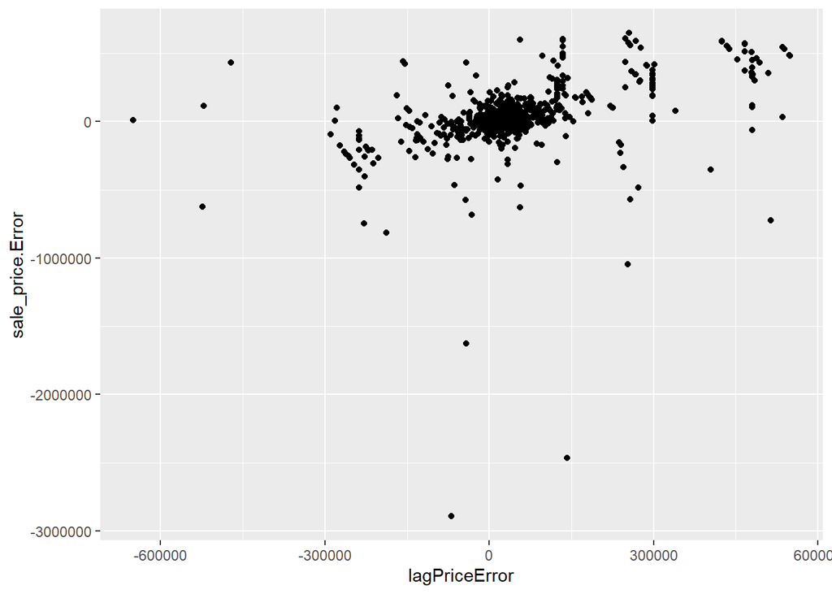

```r
coords.test <-  st_coordinates(philly_filtered.test)

neighborList.test <- knn2nb(knearneigh(coords.test, 5))

spatialWeights.test <- nb2listw(neighborList.test, style="W")

philly_filtered.test %>%
  mutate(lagPriceError = lag.listw(spatialWeights.test, sale_price.Error)) %>%
  ggplot()+
  geom_point(aes(x =lagPriceError, y =sale_price.Error))
```

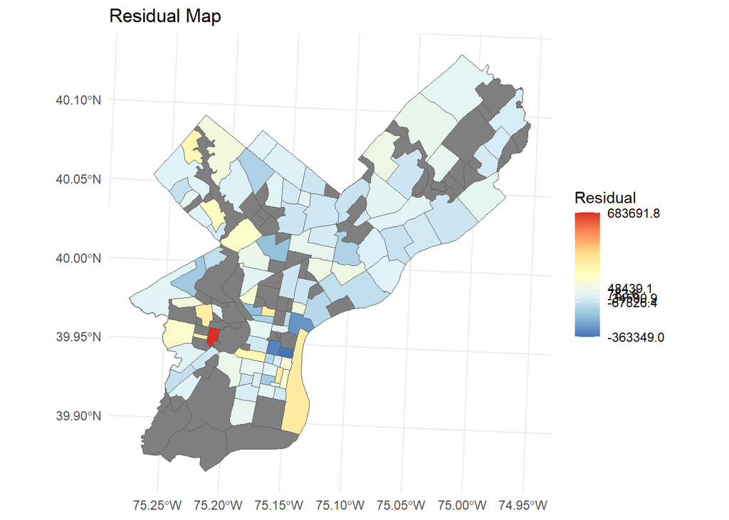

```r
philly_filtered.test$residuals <- philly_filtered.test$sale_price - philly_filtered.test$sale_price.Predict
res <- st_join(neighborhood, philly_filtered.test, by = "name")

resmap <- res %>%
  group_by(name.x)

resmap <- resmap %>%
  summarize(Mean_Residual = mean(residuals))

quantiles <- quantile(resmap$Mean_Residual, probs = seq(0, 1, by = 0.2), na.rm = TRUE)

quantile_labels <- labels <- sprintf("%0.1f", quantiles)

ggplot() +
  geom_sf(data = resmap, aes(fill = Mean_Residual)) +
  scale_fill_distiller(breaks = quantiles, labels = quantile_labels, palette = "RdYlBu", direction = -1) +
  labs(title = "Residual Map",
       fill = "Residual") +
  theme_minimal()
```

> The map is showing the residual between actual sale price and predicted sale price by neighborhood. The neighborhood in bottom left of Philadelphia shows highest residual. It means that there is the most difference between predicted and observed housing price in dollars.

# Moran’s I

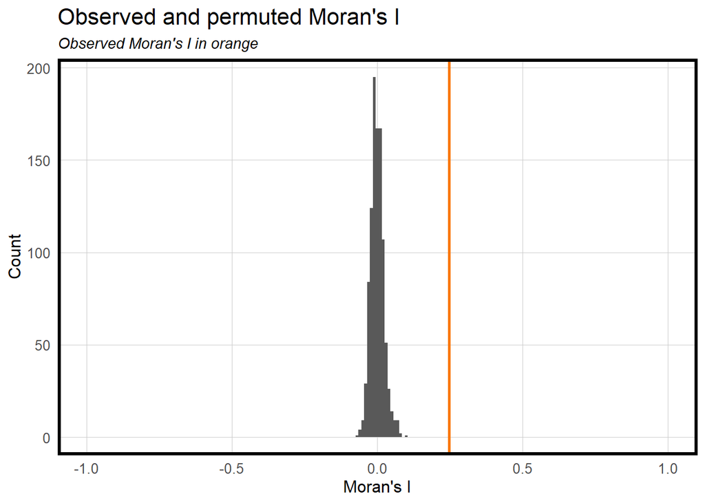

```r
moranTest <- moran.mc(philly_filtered.test$sale_price.Error,
                      spatialWeights.test, nsim = 999)

ggplot(as.data.frame(moranTest$res[c(1:999)]), aes(moranTest$res[c(1:999)])) +
  geom_histogram(binwidth = 0.01) +
  geom_vline(aes(xintercept = moranTest$statistic), colour = "#FA7800",size=1) +
  scale_x_continuous(limits = c(-1, 1)) +
  labs(title="Observed and permuted Moran's I",
       subtitle= "Observed Moran's I in orange",
       x="Moran's I",
       y="Count") +
  plotTheme()
```

> Moran’s I observed value is about 0.3. First, as the value is positive value, it has positive spatial autocorrelation. It explains that when the buildings are located in similar areas, their predicted housing prices are also similar. However, the grey line are clustered near 0.0. It means that permuted values are not showing much spatial autocorrelation between buildings.

# Predicted Map (Test Set)

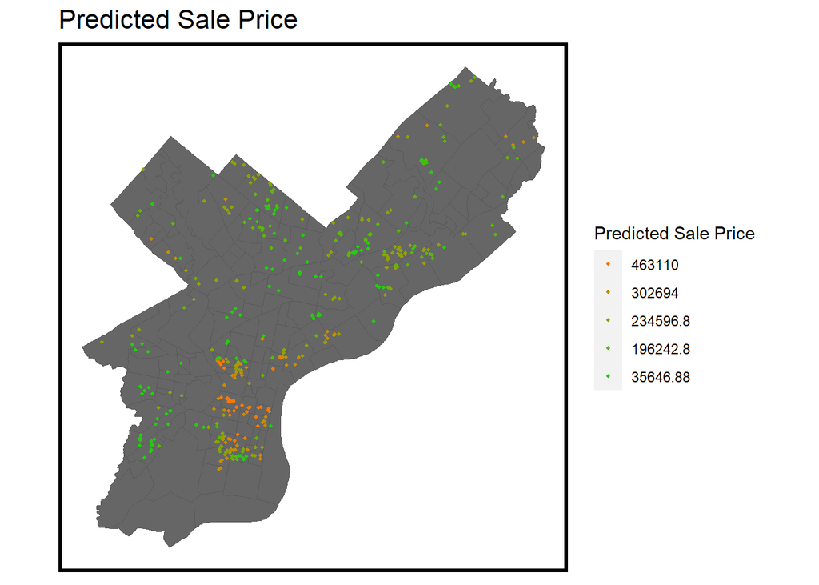

```r
# Mapping data
ggplot() +
  geom_sf(data = neighborhood, fill = "grey40") +
  geom_sf(data = philly_filtered.test, aes(colour = q5(sale_price.Predict)),
          show.legend = "point", size = .75) +
  scale_colour_manual(values = palette5,
                   labels=qBr(philly_filtered.test,"sale_price.Predict"),
                   name="Predicted Sale Price") +
  guides(color = guide_legend(reverse = TRUE)) +
  labs(title="Predicted Sale Price") +
  mapTheme()
```

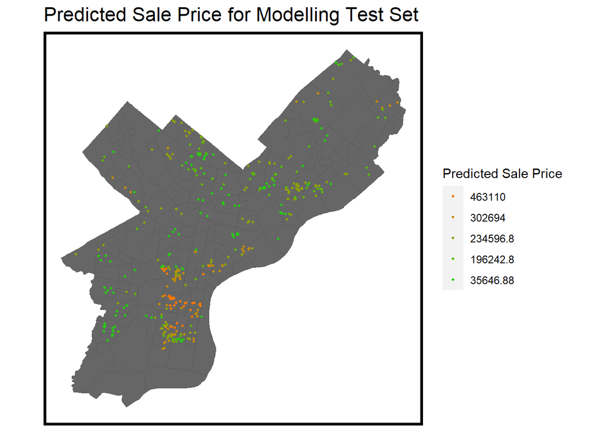

```r
# Mapping data Modelling

# Filter rows with the specified value in the "toPredict" column
modelling_philly <- filter(philly_filtered.test, toPredict == "MODELLING")


ggplot() +
  geom_sf(data = neighborhood, fill = "grey40") +
  geom_sf(data = modelling_philly, aes(colour = q5(sale_price.Predict)),
          show.legend = "point", size = .75) +
  scale_colour_manual(values = palette5,
                   labels=qBr(philly_filtered.test,"sale_price.Predict"),
                   name="Predicted Sale Price") +
  guides(color = guide_legend(reverse = TRUE)) +
  labs(title="Predicted Sale Price for Modelling Test Set") +
  mapTheme()
```

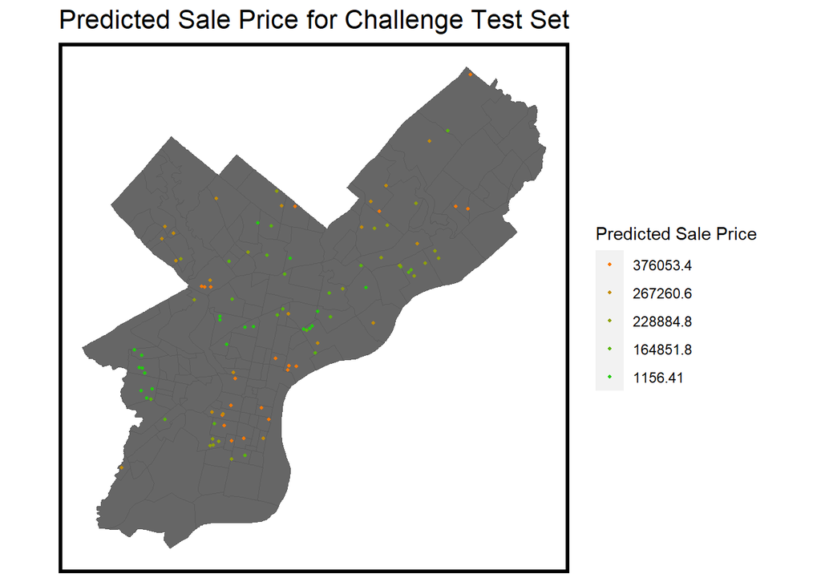

```r
# Make predictions on the new dataset
predictions <- predict(reg1, newdata = philly_challenge)

philly_challenge$Predicted_Price <- predictions

ggplot() +
  geom_sf(data = neighborhood, fill = "grey40") +
  geom_sf(data = philly_challenge, aes(colour = q5(Predicted_Price)),
          show.legend = "point", size = .75) +
  scale_colour_manual(values = palette5,
                   labels=qBr(philly_challenge,"Predicted_Price"),
                   name="Predicted Sale Price") +
  guides(color = guide_legend(reverse = TRUE)) +
  labs(title="Predicted Sale Price for Challenge Test Set") +
  mapTheme()
```

> Map of predicted housing price for MODELLING and CHALLENGE. It appears that there is not obvious pattern of the housing price by census tract. However, it is interesting to see that high predicted sale price located in the center city and bottom right Philadelphia. while low predicted sale price located in Left side of Philadelphia and Northern part of Philadelphia.

```r
reg.nhood <- lm(sale_price ~ ., data = as.data.frame(philly_filtered.training) %>%
                                 dplyr::select(name, sale_price,park.Buffer, crime.Buffer, water.Buffer,transit.Buffer, pub.Buffer, university.Buffer, landmark.Buffer, bridge.Buffer, Age, number_stories, total_area, crime.Buffer))

philly_filtered.test.nhood <-
  philly_filtered.test %>%
  mutate(Regression = "Neighborhood Effects",
         sale_price.Predict = predict(reg.nhood, philly_filtered.test),
         sale_price.Error = sale_price.Predict- sale_price,
         sale_price.AbsError = abs(sale_price.Predict- sale_price),
         sale_price.APE = (abs(sale_price.Predict- sale_price)) / sale_price)%>%
  filter(sale_price < 5000000)

bothRegressions <-
  rbind(
    dplyr::select(philly_filtered.test, starts_with("sale_price"), Regression, name) %>%
      mutate(lagPriceError = lag.listw(spatialWeights.test, sale_price.Error)),
    dplyr::select(philly_filtered.test.nhood, starts_with("sale_price"), Regression, name) %>%
      mutate(lagPriceError = lag.listw(spatialWeights.test, sale_price.Error)))

st_drop_geometry(bothRegressions) %>%
  gather(Variable, Value, -Regression, -name) %>%
  filter(Variable == "sale_price.AbsError" | Variable == "sale_price.APE") %>%
  group_by(Regression, Variable) %>%
    summarize(meanValue = mean(Value, na.rm = T)) %>%
    spread(Variable, meanValue) %>%
    kable()
```

| Regression | sale_price.AbsError | sale_price.APE |
| --- | --- | --- |
| Baseline Regression | 148554.9 | 0.4014821 |
| Neighborhood Effects | 138915.4 | 0.6170516 |

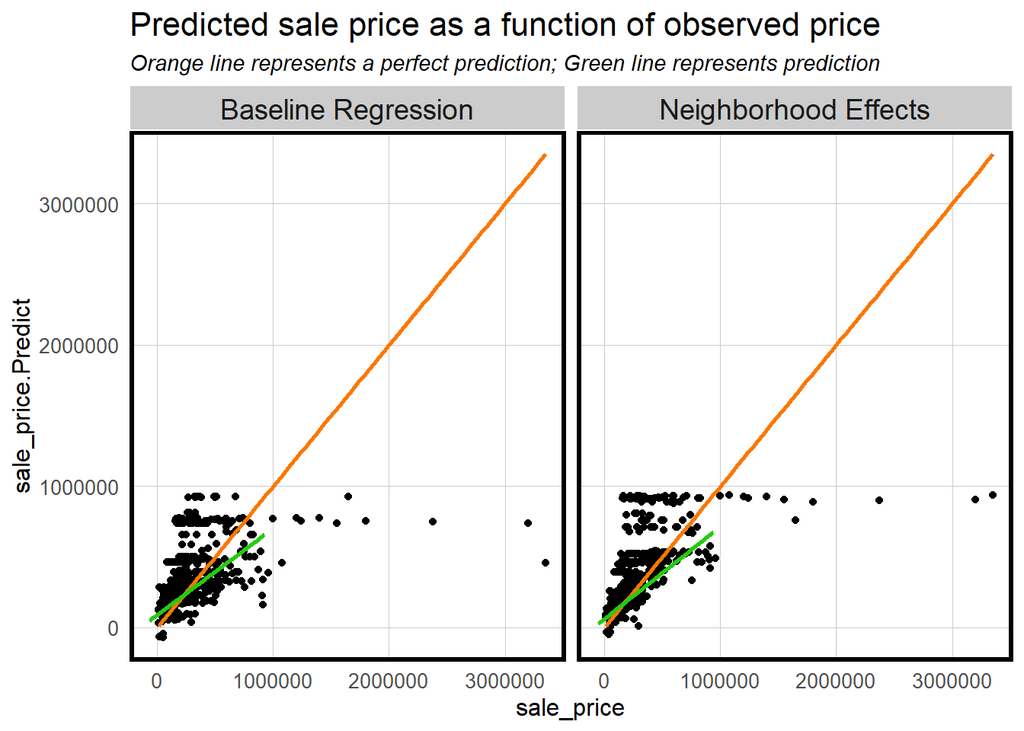

```r
bothRegressions %>%
  dplyr::select(sale_price.Predict, sale_price, Regression) %>%
    ggplot(aes(sale_price, sale_price.Predict)) +
  geom_point() +
  stat_smooth(aes(sale_price, sale_price),
             method = "lm", se = FALSE, size = 1, colour="#FA7800") +
  stat_smooth(aes(sale_price.Predict, sale_price),
              method = "lm", se = FALSE, size = 1, colour="#25CB10") +
  facet_wrap(~Regression) +
  labs(title="Predicted sale price as a function of observed price",
       subtitle="Orange line represents a perfect prediction; Green line represents prediction") +
  plotTheme()
```

> Although Neighborhood Effects Method has lower absolute error, it has higher absolute percentage error. It means that including geographical effect makes the higher MAPE.

# MAPE by Neighborhood

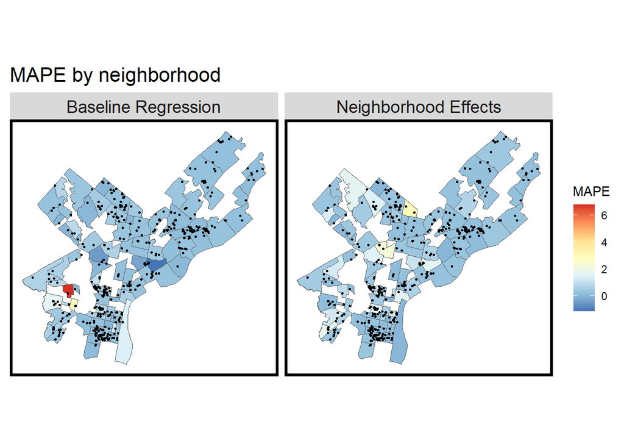

```r
st_drop_geometry(bothRegressions) %>%
  group_by(Regression, name) %>%
  summarize(mean.MAPE = mean(sale_price.APE, na.rm = T)) %>%
  ungroup() %>%
  left_join(neighborhood) %>%
    st_sf() %>%
    ggplot() +
      geom_sf(aes(fill = mean.MAPE)) +
      geom_sf(data = bothRegressions, colour = "black", size = .5) +
      facet_wrap(~Regression) +
      scale_fill_distiller(palette = "RdYlBu",
                          name = "MAPE") +
      labs(title = "MAPE by neighborhood") +
      mapTheme()
```

> The visualization shows that the higher MAPE region are different across baseline regression and neighborhood effects. For baseline regression, the highest MAPE locates at bottom left of Philadelphia. However, for neighborhood effects, MAPE value is fairly consistent across Philadelphia.

# Scatterplot - MAPE by Neighborhood

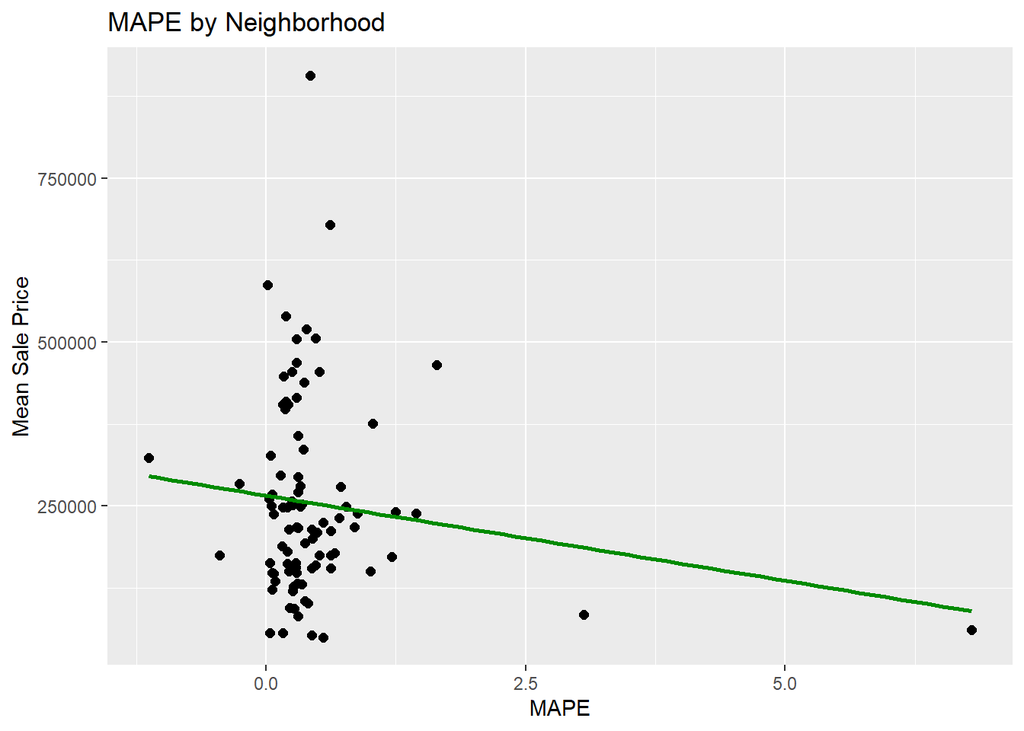

```r
# Merge point data into polygons
neigh_merged <- st_join(philly_filtered.test, neighborhood)

# Find Mean
MAPE_neigh <- neigh_merged %>%
  group_by(name.x) %>%
  summarize(MAPE = mean(sale_price.APE))
sale_neigh <- neigh_merged %>%
  group_by(cartodb_id.x) %>%
  summarize(Mean_sale_price = mean(sale_price))

# Scatterplot
ggplot(MAPE_neigh, aes(x = MAPE, y = sale_neigh$Mean_sale_price)) +
  geom_point(size = 2) + geom_smooth(method = "lm", se=F, colour = "green4") +
  labs(title = "MAPE by Neighborhood",
       x = "MAPE",
       y = "Mean Sale Price")
```

# Split by Census Group

[figure not shown]

```r
st_join(bothRegressions, tracts17) %>%
  group_by(Regression, raceContext) %>%
  summarize(mean.MAPE = scales::percent(mean(sale_price.APE, na.rm = T))) %>%
  st_drop_geometry() %>%
  spread(raceContext, mean.MAPE) %>%
  kable(caption = "Test set MAPE by neighborhood racial context")
```

Test set MAPE by neighborhood racial context

| Regression | Majority Non-White | Majority White |
| --- | --- | --- |
| Baseline Regression | 42% | 39% |
| Neighborhood Effects | 56% | 65% |

```r
st_join(bothRegressions, tracts17) %>%
  filter(!is.na(incomeContext)) %>%
  group_by(Regression, incomeContext) %>%
  summarize(mean.MAPE = scales::percent(mean(sale_price.APE, na.rm = T))) %>%
  st_drop_geometry() %>%
  spread(incomeContext, mean.MAPE) %>%
  kable(caption = "Test set MAPE by neighborhood income context")
```

Test set MAPE by neighborhood income context

| Regression | High Income | Low Income |
| --- | --- | --- |
| Baseline Regression | 47% | 34% |
| Neighborhood Effects | 84% | 44% |

# Discussion - Accuracy

> Accuracy of prediction using our own model cannot be said as accurate model. First of all, the value of MAE is pretty huge. It means that there are large difference between observed and predicted value. It will lead to the result of the predicted housing price of the test set. In addition, RMSE value is high compared to the range of the housing price. However, from the linear line from the scatterplot of observed and predicted housing price, we can see that it has the correct trend of housing price.

# Discussion - Generalizability

> Generalizability is to figure out whether the spatial trend of the predicted housing price is well predicted. R-squared value is at 45%, so it proved that the model included decent degree of spatial trend, but it is hard to say that the model has good generalizability. Also, standard deviation of MAE is relatively high compared to the range of housing price. These statistical indicators shows that generalizability of the model is not high enough to make the predicted housing price as credible.

# Conclusion & Recommendation

> In conclusion, our model to predict the housing price was not good enough to help consumers who are willing to buy a house. Hence, we do not recommend our model to Zillow. Although they were merely helpful in both accuracy and generalizability, it is not good enough to be a credible model. It would have been better to include more indicators that we couldn’t figure out for this project. There were limit of finding enough open data indicators, as many of the interesting and useful data have to be purchased. Furthermore, it would have been better if we had better understanding on statistics. Throughout the project, we realized that applying statistical knowledge is different from the texts from the book. There were many variables that we have to consider to get clear statistical understandings.